# Reproducible Research: Peer Graded Assignment - Course Project 2

Christian Frei

26 August 2016

# Reproducible Research: Peer Graded Assignment - Course Project 2

## Goal

The basic goal of this analysis is to explore the NOAA Storm Database and answer two questions concerning severe weather events:

- Which severe weather events (EVTYPE) are most harmful with respect to population health?
- Which severe weather events have the greatest economic consequences?

## NOAA Storm Database

The data for this assignment come in the form of a comma-separated-value file compressed via the bzip2 algorithm to reduce its size. You can download the file from the course web site:

[Storm Data](https://d396qusza40orc.cloudfront.net/repdata%2Fdata%2FStormData.csv.bz2) [47MB]

There is also some documentation of the database available. Here you will find how some of the variables are constructed/defined.

- National Weather Service [Storm Data Documentation](https://d396qusza40orc.cloudfront.net/repdata%2Fpeer2_doc%2Fpd01016005curr.pdf)
- National Climatic Data Center Storm Events [FAQ](https://d396qusza40orc.cloudfront.net/repdata%2Fpeer2_doc%2FNCDC%20Storm%20Events-FAQ%20Page.pdf)

The events in the database start in the year 1950 and end in November 2011. In the earlier years of the database there are generally fewer events recorded, most likely due to a lack of good records. More recent years should be considered more complete.

## Libraries and Option

```r
library("ggplot2")
library("reshape")
library('scales')
options(scipen=999)
```

## Data Analysis

### Download Storm Data “StormData.csv.bz2”, extract and load CSV file

First steps of data preparation is to download, extract and load data in to R.

```r
# Init variables about zipfilename and fileURL
zipFileName <- "StormData.csv.bz2"
fileURL <- "https://d396qusza40orc.cloudfront.net/repdata%2Fdata%2FStormData.csv.bz2"

# If file isn't stored, it will be downloaded.
if (!file.exists(zipFileName)){
  download.file(fileURL, zipFileName, method="curl")
}

# Load CSV file
data <- read.csv(zipFileName, stringsAsFactors = FALSE)
```

### Data Preparation

After data is loaded in R, next step is preparing data for the analysis.

#### Time

Therefore data from Jan 1966 or later are kept for this analysis.

Futher details may be found [here](http://www.ncdc.noaa.gov/stormevents/details.jsp).

```r
# Convert the date from factor to to a date field.
data$BGN_DATE <- as.Date(data$BGN_DATE, format = "%m/%d/%Y")

# Data as of January 1, 1966 is only taken for this analysis.
data <- subset(data, BGN_DATE >= as.Date("1966-01-01"))
```

#### Columns

Due to the large size of columns, only necessary columns are kept for this analysis.

- BGN_DATE - Event Begin Date
- EVTYPE - Event Type
- FATALITIES - Number of reported fatalities caused by the event.
- INJURIES - Number of reported injuries caused by the event.
- PROPDMG/PROPDMGEXP - The dollar (USD) amount of property damage caused by the event.
- CROPDMG/CROPDMGEXP - The dollar (USD) amount of crop damage caused by the event.

```r
# Necessary columns for the analysis which are kept for this analysis.
neededCols <- c("BGN_DATE",
                  "EVTYPE",
                  "FATALITIES",
                  "INJURIES",
                  "PROPDMG",
                  "PROPDMGEXP",
                  "CROPDMG",
                  "CROPDMGEXP")

# Take only cols and rows which are needed for this analysis.
data <- subset(data,
               select = neededCols,
               (grepl(EVTYPE, pattern = "*Summary*", ignore.case = TRUE) == FALSE))
```

Adjustment of Several Event Type Names According to Storm Data [Documentation](https://d396qusza40orc.cloudfront.net/repdata%2Fpeer2_doc%2Fpd01016005curr.pdf)(page 6), names must be written out, because some are represented in more than one name, such as “TSTM WIND” and “THUNDERSTORM WIND”.

```r
data[data$EVTYPE == "TSTM WIND", ]$EVTYPE = "THUNDERSTORM WIND"
data[data$EVTYPE == "THUNDERSTORM WINDS", ]$EVTYPE = "THUNDERSTORM WIND"
data[data$EVTYPE == "RIVER FLOOD", ]$EVTYPE = "FLOOD"
data[data$EVTYPE == "HURRICANE/TYPHOON", ]$EVTYPE = "HURRICANE-TYPHOON"
data[data$EVTYPE == "HURRICANE", ]$EVTYPE = "HURRICANE-TYPHOON"
```

### Conversion of Damage Amounts

The damage amounts are stored in the data as a pair of columns. One is the “DMG” amount (PROPDMG/CROPDMG). The other is “DMGEXP”" which is the dimension to apply a magnitude to the amount (PROPDMGEXP/CROPDMGEXP). e.g. DMG x 10 ^ DMGEXP

The distinct exponent symbols are identified so that they may be quantified individually.

```r
# Create a dictanry for lookup exponents.
exponentLookup <- data.frame(DMGEXP = c("",
                                        "-",
                                        "?",
                                        "+",
                                        "0",
                                        "1",
                                        "2",
                                        "3",
                                        "4",
                                        "5",
                                        "6",
                                        "7",
                                        "8",
                                        "B",
                                        "H",
                                        "K",
                                        "M"
                                        ),
                             EXP = c(1,          #
                                     1,          # -
                                     1,          # ?
                                     1,          # +
                                     1,          # 0
                                     10,         # 1
                                     100,        # 2
                                     1000,       # 3
                                     10000,      # 4
                                     100000,     # 5
                                     1000000,    # 6
                                     10000000,   # 7
                                     100000000,  # 8
                                     1000000000, # B
                                     100,        # H
                                     1000,       # K
                                     1000000     # M
                                    ),
                             stringsAsFactors = FALSE
                             )

# If DMGEXP has small letters convert them into capital letters
data$PROPDMGEXP <- toupper(data$PROPDMGEXP)
data$CROPDMGEXP <- toupper(data$CROPDMGEXP)

# Merge the power of exponents for use with property damage amounts.
data <- merge(x = data, y = exponentLookup,
                by.x = "PROPDMGEXP", by.y = "DMGEXP",
                all.x = TRUE)
names(data)[names(data)== "EXP"] <- "PROPEXP"

data <- merge(x = data, y = exponentLookup,
                by.x = "CROPDMGEXP", by.y = "DMGEXP",
                all.x = TRUE)
names(data)[names(data)== "EXP"] <- "CROPEXP"

# Apply the power of to the damage amounts
data$PropDamageAmount <- data$PROPDMG * data$PROPEX
data$CropDamageAmount <- data$CROPDMG  * data$CROPEXP
```

### Clean Texts of Event Type (EVTYPE)

```r
# A general function "clean" of modifications to apply to all event type values.
clean <- function(x) {
  x <- toupper(x) # use consistent casing
  x <- sub("\\\\", " ", x) # eliminate \'s
  x <- sub("-", " ", x) # eliminate -'s
  x <- sub("/", " ", x) # eliminate /'s
  x <- gsub("\\s+", " ", x) # compress multiple spaces
  x <- trimws(x) # trim leading and trailing whitespace
}

data$EVTYPE <- apply(data.frame(data$EVTYPE), 2, clean)
```

## Analysis

### Population Health

The top 5 weather events, which have an impact to fatalities and injuries, will be ranked.

```r
# Top 5 Severe Weather Events for Fatality
fatalityTop5 <- aggregate(list(Freq=data$FATALITIES),
                              list(EventType=data$EVTYPE),
                              sum)
fatalityTop5 <- head(fatalityTop5[order(-fatalityTop5$Freq),], n=5)

# Top 5 Severe Weather Events for Injury
injuryTop5 <- aggregate(list(Freq=data$INJURIES),
                            list(EventType=data$EVTYPE),
                            sum)
injuryTop5 <- head(injuryTop5[order(-injuryTop5$Freq),], n=5)
```

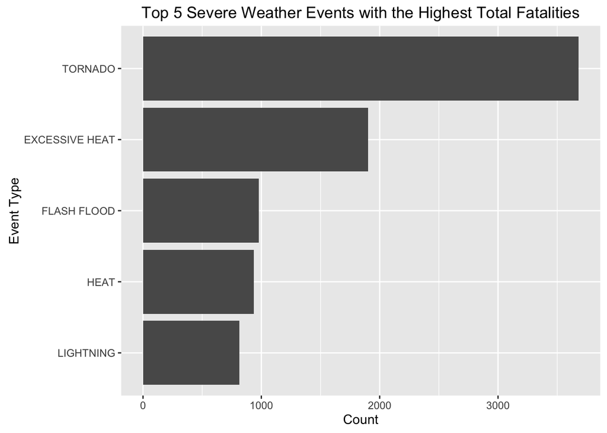

```r
ggplot(data=fatalityTop5, aes(x=reorder(EventType, Freq), y=Freq)) +
    geom_bar(stat="identity") +
    ggtitle(label = "Top 5 Severe Weather Events with the Highest Total Fatalities") +
    labs(x = "Event Type", y = "Count") +
    coord_flip()
```

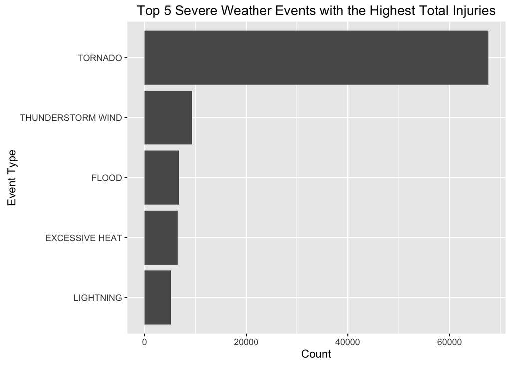

```r
ggplot(data=injuryTop5, aes(x=reorder(EventType, Freq), y=Freq)) +
    geom_bar(stat="identity") +
    ggtitle(label = "Top 5 Severe Weather Events with the Highest Total Injuries") +
    labs(x = "Event Type", y = "Count") +
    coord_flip()
```

Tornados has at fatalities and injuries the highest number.

### Economic Consequences

To analyze the top contributing weather events by total cost of damage, the total of both damage amounts (property and crop) will be calculated and ranked.

```r
# Calculte the costs of damage for property and for crop.
PropertyDamageTop5 <- aggregate(
                               list(PropDamageAmount=data$PropDamageAmount,
                                    CropDamageAmount=data$CropDamageAmount),
                               list(EVTYPE=data$EVTYPE),
                               sum)

# Calculate the total costs
PropertyDamageTop5$TotalDamageAmount <- PropertyDamageTop5$PropDamageAmount + PropertyDamageTop5$CropDamageAmount

# Top 5 Contributing Severe Weather Events for Total Economic Damage
PropertyDamageTop5 <- PropertyDamageTop5[order(-PropertyDamageTop5$TotalDamageAmount),]
PropertyDamageTop5 <- head(PropertyDamageTop5, n=5)

# Reorganize PropertyDamageTop5 to 3 columns EVTYPE, variable, value
PropertyDamageTop5 <- melt(PropertyDamageTop5[,-4])
names(PropertyDamageTop5)[names(PropertyDamageTop5) == "variable"] <- "TypOfDamage"
names(PropertyDamageTop5)[names(PropertyDamageTop5) == "value"] <- "Amount"

# Rename PropDamageAmount and CropDamageAmount
levels(PropertyDamageTop5$TypOfDamage)[levels(PropertyDamageTop5$TypOfDamage) == "PropDamageAmount"] <- "Property Damage Amount"
levels(PropertyDamageTop5$TypOfDamage)[levels(PropertyDamageTop5$TypOfDamage) == "CropDamageAmount"] <- "Crop Damage Amount"
```

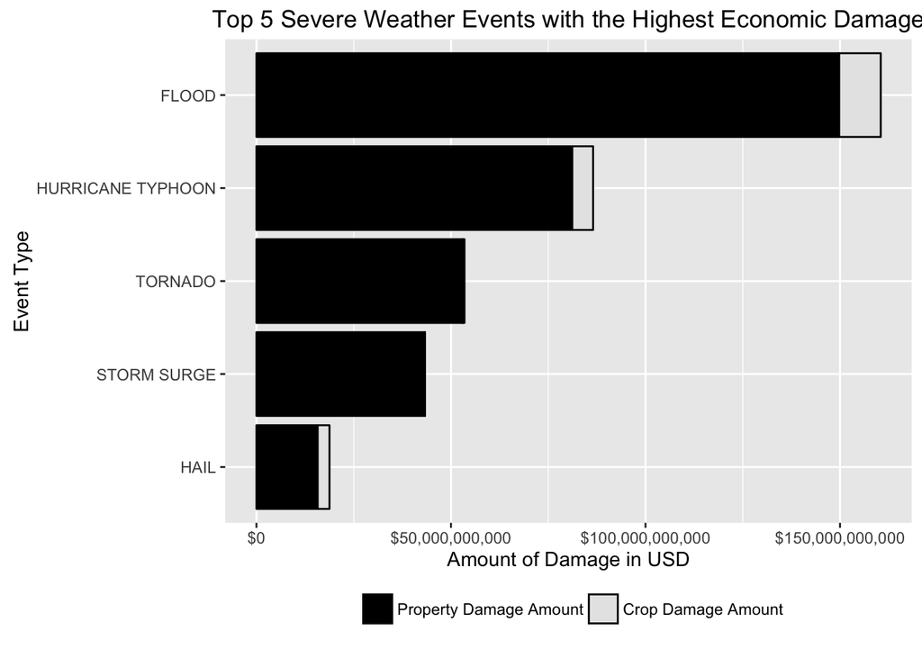

```r
ggplot(data=PropertyDamageTop5,
      aes(x=reorder(EVTYPE, Amount), y=Amount, fill=TypOfDamage)) +
      scale_fill_grey(start = 0, end = 0.9) +
      theme(legend.position="bottom") +
      guides(fill=guide_legend(title=NULL)) +
      geom_bar(stat="identity", colour="black") +
      ggtitle(label = "Top 5 Severe Weather Events with the Highest Economic Damage") +
      labs(x = "Event Type", y = "Amount of Damage in USD") +
      scale_y_continuous(labels = dollar) +
      coord_flip()
```

Floods are the highest contributor economic loss. It is doubled of hurricane typhoon ,which is 2nd. Tornados, which is the highest contributor for fatalities and injuries, is just 3rd ranking event to economic damage. For these severe weather event types, costs for property damage is much higher than for crops damage.